# Results of CA using NDNS RP (food group and timeslots)

Chaochen Wang

8/7/2019

# 1 Pre-CA analyses

## 1.1 Summary statistics

In this section, we look at some of the summary statistics for our NDNS RP (9 year) dataset in adults (age >= 19 y.o.). After excluding food recordings from young participants, there were 749,026 recordings of food entry written by the 6802 pariticipants.

### 1.1.1 numbers of food entries by time slots (7 or 3 groups)

```r
load("../Food1_9_adlt_labl.Rdata")

Food1_9_adlt %>%
  ungroup() %>%
  group_by(MealTimeSlot) %>%
  summarise(n = n()) %>%
  mutate(relfreq = n/sum(n)) %>%
  mutate(rel.freq = paste0(round(100 * n/sum(n), 3), "%"))  %>%
  mutate(cum.freq = paste0(round(100 * cumsum(relfreq), 3), "%")) %>%
  print(n=Inf)
```

```
## # A tibble: 7 x 5
##   MealTimeSlot           n relfreq rel.freq cum.freq
##   <fct>              <int>   <dbl> <chr>    <chr>
## 1 6am to 8:59am     107144  0.143  14.304%  14.304%
## 2 9am to 11:59am    110614  0.148  14.768%  29.072%
## 3 12 noon to 1:59pm 138183  0.184  18.448%  47.521%
## 4 2pm to 4:59pm      94606  0.126  12.631%  60.151%
## 5 5pm to 7:59pm     180498  0.241  24.098%  84.249%
## 6 8pm to 9:59pm      81716  0.109  10.91%   95.158%
## 7 10pm to 5:59am     36265  0.0484 4.842%   100%
```

```r
Food1_9_adlt %>%
  ungroup() %>%
  group_by(Time3g) %>%
  summarise(n = n()) %>%
  mutate(relfreq = n/sum(n)) %>%
  mutate(rel.freq = paste0(round(100 * n/sum(n), 3), "%"))  %>%
  mutate(cum.freq = paste0(round(100 * cumsum(relfreq), 3), "%")) %>%
  print(n=Inf)
```

```
## # A tibble: 3 x 5
##   Time3g         n relfreq rel.freq cum.freq
##   <fct>      <int>   <dbl> <chr>    <chr>
## 1 Morning   217758   0.291 29.072%  29.072%
## 2 Afternoon 413287   0.552 55.177%  84.249%
## 3 Evening   117981   0.158 15.751%  100%
```

### 1.1.2 Days of week collected in the dataset

```r
Food1_9_adlt %>%
  mutate(DayofWeek = factor(DayofWeek, levels = c("Monday",
                                                  "Tuesday",
                                                  "Wednesday",
                                                  "Thursday",
                                                  "Friday",
                                                  "Saturday",
                                                  "Sunday"))) %>%
  ungroup() %>%
  group_by(DayofWeek) %>%
  summarise(n = n()) %>%
  mutate(relfreq = n/sum(n)) %>%
  mutate(rel.freq = paste0(round(100 * n/sum(n), 3), "%"))  %>%
  mutate(cum.freq = paste0(round(100 * cumsum(relfreq), 3), "%")) %>%
  print(n=Inf)
```

```
## # A tibble: 7 x 5
##   DayofWeek      n relfreq rel.freq cum.freq
##   <fct>      <int>   <dbl> <chr>    <chr>
## 1 Monday    104922   0.140 14.008%  14.008%
## 2 Tuesday   102039   0.136 13.623%  27.631%
## 3 Wednesday 100621   0.134 13.434%  41.064%
## 4 Thursday  104898   0.140 14.005%  55.069%
## 5 Friday    112669   0.150 15.042%  70.111%
## 6 Saturday  111405   0.149 14.873%  84.984%
## 7 Sunday    112472   0.150 15.016%  100%
```

### 1.1.3 Sex and age

The participants were:

- 2810 men (sex = 1) and
- 3992 women (sex = 2) aged 19 or above.

```r
load("../Indiv1_9_adlt.Rdata")
Indiv1_9_adlt$Sex <- factor(Indiv1_9_adlt$Sex)
Indiv1_9_adlt %>%
  group_by(Sex) %>%
  summarise(Meanage = mean(age),
            SDage = sd(age))
```

```
## # A tibble: 2 x 3
##   Sex   Meanage SDage
##   <fct>   <dbl> <dbl>
## 1 1        50.4  17.2
## 2 2        49.6  17.8
```

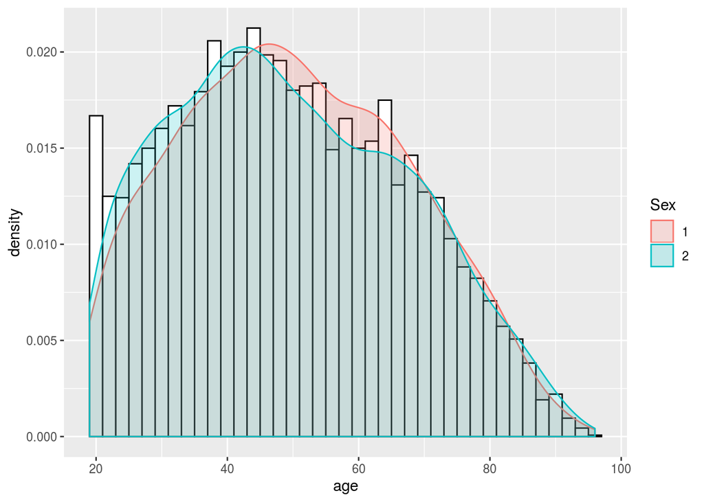

```r
ggplot(Indiv1_9_adlt, aes(x=age, fill = Sex, color = Sex)) +
 geom_histogram(aes(y=..density..), colour="black", fill="white", binwidth = 2)+
 geom_density(alpha=.2)
```

### 1.1.4 Diabetes status

In all 9 years data combined, there were:

- 227 diabetes patients (DM4cat = 3);
- 99 undiagnosed diabetes (DM4cat = 2);
- 133 prediabetes (DM4cat = 1);
- 3717 missing values.

```r
load("../Indiv1_9_adlt.Rdata")

Indiv1_9_adlt %>%
  group_by(DM4cat) %>%
  summarise(n = n()) %>%
  mutate(rel.freq = paste0(round(100 * n/sum(n), 2), "%"))  %>%
  print(n=Inf)
```

```
## # A tibble: 5 x 3
##   DM4cat     n rel.freq
##    <dbl> <int> <chr>
## 1      0  2626 38.61%
## 2      1   133 1.96%
## 3      2    99 1.46%
## 4      3   227 3.34%
## 5     NA  3717 54.65%
```

### 1.1.5 Social economic status

121 pariticipants’ socio-economic classification were missing.

```r
library(naniar)

Indiv1_9_adlt %>%
  replace_with_na(replace = list(nssec8 = -9)) %>%
  group_by(nssec8) %>%
  summarise(n = n()) %>%
  mutate(relfreq = n/sum(n)) %>%
  mutate(rel.freq = paste0(round(100 * n/sum(n), 3), "%"))  %>%
  mutate(cum.freq = paste0(round(100 * cumsum(relfreq), 3), "%")) %>%
  print(n=Inf)
```

```
## # A tibble: 9 x 5
##   nssec8     n relfreq rel.freq cum.freq
##    <dbl> <int>   <dbl> <chr>    <chr>
## 1      1  1032  0.152  15.172%  15.172%
## 2      2  1632  0.240  23.993%  39.165%
## 3      3   672  0.0988 9.879%   49.044%
## 4      4   727  0.107  10.688%  59.732%
## 5      5   630  0.0926 9.262%   68.994%
## 6      6   972  0.143  14.29%   83.284%
## 7      7   819  0.120  12.041%  95.325%
## 8      8   197  0.0290 2.896%   98.221%
## 9     NA   121  0.0178 1.779%   100%
```

## 1.2 Food groups

All 60 food groups sorted by the percentage contributed to the total calories consumed by participants. We can see 13 food groups contributed 50% of total energy that these pariticipants consumed, 28 food groups contributed 80% of total energy that these people consumed.

```r
TableFoogGroup <- Food1_9_adlt %>%
  ungroup() %>%
  group_by(mfgLab) %>%
  summarise(n = n(), meanHpoint = mean(H_points, na.rm = T), mfgCalories = sum(Energykcal)) %>%
  arrange(-mfgCalories) %>%
  mutate(n.freq = paste0(round(100 * n/sum(n), 2), "%"))  %>%
  mutate(cal.Prop = paste0(round(100 * mfgCalories/sum(mfgCalories), 2), "%"))  %>%
  mutate(calprop = mfgCalories/sum(mfgCalories)) %>%
  mutate(calcumprop = paste0(round(100 * cumsum(calprop), 3), "%")) %>%
  select(-calprop) %>%
  print(n=Inf)
```

```
## # A tibble: 60 x 7
##    mfgLab               n meanHpoint mfgCalories n.freq cal.Prop calcumprop
##    <chr>            <int>      <dbl>       <dbl> <chr>  <chr>    <chr>
##  1 Pasta & Rice     18353    -0.301     3512070. 2.45%  7.36%    7.362%
##  2 White Bread      18434     3.61      3245641. 2.46%  6.8%     14.166%
##  3 Chips             6749     0.0935    1884059. 0.9%   3.95%    18.116%
##  4 Cakes & Pastri…   7806    17.3       1710594. 1.04%  3.59%    21.701%
##  5 Veg not raw      51317    -7.03      1665474. 6.85%  3.49%    25.193%
##  6 Biscuits         13200    18.3       1662598. 1.76%  3.49%    28.678%
##  7 Fruit            33903    -2.81      1641675. 4.53%  3.44%    32.12%
##  8 Misc./Vending    48597     9.49      1639025. 6.49%  3.44%    35.555%
##  9 Chicken/turkey    8863     0.534     1617820. 1.18%  3.39%    38.947%
## 10 Cheese           10983    21.5       1492015. 1.47%  3.13%    42.074%
## 11 Beer lager        8199     0.990     1484001. 1.09%  3.11%    45.185%
## 12 2% milk          57611     1.02      1302650. 7.69%  2.73%    47.916%
```

[output cut: 48 more lines]

### 1.2.1 Healthy point definition by (Pechey et al, 2013)

#### 1.2.1.1 Healthy foods (n = 3) meanHpoint < -2

```r
TableFoogGroup <- TableFoogGroup %>%
  mutate(healthy     = meanHpoint < -2,
         lesshealthy = meanHpoint > 4,
         neutral     = (meanHpoint <= 4) & (meanHpoint >= -2))

TableFoogGroup %>%
  filter(healthy) %>%
  select(-lesshealthy, -neutral,-calcumprop)
```

```
## # A tibble: 3 x 7
##   mfgLab                n meanHpoint mfgCalories n.freq cal.Prop healthy
##   <chr>             <int>      <dbl>       <dbl> <chr>  <chr>    <lgl>
## 1 Veg not raw       51317      -7.03    1665474. 6.85%  3.49%    TRUE
## 2 Fruit             33903      -2.81    1641675. 4.53%  3.44%    TRUE
## 3 Salad and raw veg 33263      -7.03     297085. 4.44%  0.62%    TRUE
```

#### 1.2.1.2 Neutral foods (n = 26); meanHpoint between (-2, 4)

```r
TableFoogGroup %>%
  filter(neutral) %>%
  select(-lesshealthy, -healthy, -calcumprop) %>%
  print(n=Inf)
```

```
## # A tibble: 26 x 7
##    mfgLab                  n meanHpoint mfgCalories n.freq cal.Prop neutral
##    <chr>               <int>      <dbl>       <dbl> <chr>  <chr>    <lgl>
##  1 Pasta & Rice        18353    -0.301     3512070. 2.45%  7.36%    TRUE
##  2 White Bread         18434     3.61      3245641. 2.46%  6.8%     TRUE
##  3 Chips                6749     0.0935    1884059. 0.9%   3.95%    TRUE
##  4 Chicken/turkey       8863     0.534     1617820. 1.18%  3.39%    TRUE
##  5 Beer lager           8199     0.990     1484001. 1.09%  3.11%    TRUE
##  6 2% milk             57611     1.02      1302650. 7.69%  2.73%    TRUE
##  7 Potatos other       10113    -1.49      1291448. 1.35%  2.71%    TRUE
##  8 Beef                 4987     2.34      1124560. 0.67%  2.36%    TRUE
##  9 HiFi cereals         8215     2.78      1072814. 1.1%   2.25%    TRUE
## 10 WMeal Bread          7193     2.08      1070696. 0.96%  2.24%    TRUE
## 11 Wine                 6967     1.33      1027793. 0.93%  2.15%    TRUE
## 12 Brown Bread          6183     1.11      1009075. 0.83%  2.12%    TRUE
## 13 Eggs                 7554     3.70       964769. 1.01%  2.02%    TRUE
## 14 Reg soft drinks     11387     3.31       940517. 1.52%  1.97%    TRUE
## 15 Yogurt               6776     3.22       665485. 0.9%   1.4%     TRUE
## 16 Whole Milk          13628     2.24       530449. 1.82%  1.11%    TRUE
## 17 White fish, shell…   1597     3.99       498929. 0.21%  1.05%    TRUE
## 18 Pork                 1832     3.88       420504. 0.24%  0.88%    TRUE
## 19 Fruit juice          6960     1.79       419867. 0.93%  0.88%    TRUE
## 20 Other white fish     3703     1.28       355118. 0.49%  0.74%    TRUE
## 21 Tea/Coffee/Water   152108    -0.245      175659. 20.31% 0.37%    TRUE
## 22 Skimmed Milk         9683    -0.545      168679. 1.29%  0.35%    TRUE
## 23 Diet soft drinks    14155     0.321       32855. 1.89%  0.07%    TRUE
## 24 1% milk              1263     0.973       27534. 0.17%  0.06%    TRUE
## 25 Smoothies             137     2.93        17061. 0.02%  0.04%    TRUE
## 26 Artificial Sweete…   7518     1.60         2689. 1%     0.01%    TRUE
```

#### 1.2.1.3 Less Healthy foods (n = 31); meanHpoint > 4

```r
TableFoogGroup %>%
  filter(lesshealthy) %>%
  select(-neutral, -healthy, -calcumprop) %>%
  print(n=Inf)
```

```
## # A tibble: 31 x 7
##    mfgLab              n meanHpoint mfgCalories n.freq cal.Prop lesshealthy
##    <chr>           <int>      <dbl>       <dbl> <chr>  <chr>    <lgl>
##  1 Cakes & Pastri…  7806      17.3     1710594. 1.04%  3.59%    TRUE
##  2 Biscuits        13200      18.3     1662598. 1.76%  3.49%    TRUE
##  3 Misc./Vending   48597       9.49    1639025. 6.49%  3.44%    TRUE
##  4 Cheese          10983      21.5     1492015. 1.47%  3.13%    TRUE
##  5 JamsSpreads     37960      14.7     1215279. 5.07%  2.55%    TRUE
##  6 Chocolate        6495      24.9     1046113. 0.87%  2.19%    TRUE
##  7 Butter          10203      24.3      965901. 1.36%  2.02%    TRUE
##  8 Spreads less-f… 12620      23.4      848835. 1.68%  1.78%    TRUE
##  9 Crisps           5664      13.0      835672. 0.76%  1.75%    TRUE
## 10 Sausages         3025      15.3      775004. 0.4%   1.62%    TRUE
## 11 Meat pastries    1979      14.8      744640. 0.26%  1.56%    TRUE
## 12 Bacon and ham    8467      15.5      738727. 1.13%  1.55%    TRUE
```

[output cut: 19 more lines]

### 1.2.2 Healthy point definition by tertiles of meanHpoint

```r
TableFoogGroup <- TableFoogGroup %>%
  mutate(HealthPoints3g = ntile(meanHpoint, 3))
```

#### 1.2.2.1 Healthy foods Group 1 (n = 20)

```r
TableFoogGroup %>%
  filter(HealthPoints3g == 1) %>%
  select(-lesshealthy, -neutral,-calcumprop, -healthy, -HealthPoints3g) %>%
  print(n=Inf)
```

```
## # A tibble: 20 x 6
##    mfgLab                     n meanHpoint mfgCalories n.freq cal.Prop
##    <chr>                  <int>      <dbl>       <dbl> <chr>  <chr>
##  1 Pasta & Rice           18353    -0.301     3512070. 2.45%  7.36%
##  2 Chips                   6749     0.0935    1884059. 0.9%   3.95%
##  3 Veg not raw            51317    -7.03      1665474. 6.85%  3.49%
##  4 Fruit                  33903    -2.81      1641675. 4.53%  3.44%
##  5 Chicken/turkey          8863     0.534     1617820. 1.18%  3.39%
##  6 Beer lager              8199     0.990     1484001. 1.09%  3.11%
##  7 2% milk                57611     1.02      1302650. 7.69%  2.73%
##  8 Potatos other          10113    -1.49      1291448. 1.35%  2.71%
##  9 WMeal Bread             7193     2.08      1070696. 0.96%  2.24%
## 10 Wine                    6967     1.33      1027793. 0.93%  2.15%
## 11 Brown Bread             6183     1.11      1009075. 0.83%  2.12%
## 12 Whole Milk             13628     2.24       530449. 1.82%  1.11%
## 13 Fruit juice             6960     1.79       419867. 0.93%  0.88%
## 14 Other white fish        3703     1.28       355118. 0.49%  0.74%
## 15 Salad and raw veg      33263    -7.03       297085. 4.44%  0.62%
## 16 Tea/Coffee/Water      152108    -0.245      175659. 20.31% 0.37%
## 17 Skimmed Milk            9683    -0.545      168679. 1.29%  0.35%
## 18 Diet soft drinks       14155     0.321       32855. 1.89%  0.07%
## 19 1% milk                 1263     0.973       27534. 0.17%  0.06%
## 20 Artificial Sweeteners   7518     1.60         2689. 1%     0.01%
```

#### 1.2.2.2 Healthy foods Group 2 (n = 20)

```r
TableFoogGroup %>%
  filter(HealthPoints3g == 2) %>%
  select(-lesshealthy, -neutral,-calcumprop, -healthy, -HealthPoints3g)
```

```
## # A tibble: 20 x 6
##    mfgLab                    n meanHpoint mfgCalories n.freq cal.Prop
##    <chr>                 <int>      <dbl>       <dbl> <chr>  <chr>
##  1 White Bread           18434       3.61    3245641. 2.46%  6.8%
##  2 Misc./Vending         48597       9.49    1639025. 6.49%  3.44%
##  3 Beef                   4987       2.34    1124560. 0.67%  2.36%
##  4 HiFi cereals           8215       2.78    1072814. 1.1%   2.25%
##  5 Eggs                   7554       3.70     964769. 1.01%  2.02%
##  6 Reg soft drinks       11387       3.31     940517. 1.52%  1.97%
##  7 Yogurt                 6776       3.22     665485. 0.9%   1.4%
##  8 LoFi cereals           4303      11.6      560296. 0.57%  1.17%
##  9 Nuts and seeds         6259       4.37     559874. 0.84%  1.17%
## 10 Oily fish              2610       6.21     550425. 0.35%  1.15%
## 11 White fish, shellfish  1597       3.99     498929. 0.21%  1.05%
## 12 Puddings               2291       8.40     459785. 0.31%  0.96%
## 13 Other Milk Cream       6605      11.6      434239. 0.88%  0.91%
## 14 Pork                   1832       3.88     420504. 0.24%  0.88%
## 15 Coated Chicken         1170       6.43     359773. 0.16%  0.75%
## 16 Lamb                   1251       6.42     342289. 0.17%  0.72%
## 17 Spirits and liqueurs   2698       4.03     286589. 0.36%  0.6%
## 18 Oth Bread               932       4.96     149552. 0.12%  0.31%
## 19 Dietary supplements   13016       5.16      44916. 1.74%  0.09%
## 20 Smoothies               137       2.93      17061. 0.02%  0.04%
```

#### 1.2.2.3 Healthy foods Group 3 (n = 20)

```r
TableFoogGroup %>%
  filter(HealthPoints3g == 3) %>%
  select(-lesshealthy, -neutral,-calcumprop, -healthy, -HealthPoints3g)
```

```
## # A tibble: 20 x 6
##    mfgLab                        n meanHpoint mfgCalories n.freq cal.Prop
##    <chr>                     <int>      <dbl>       <dbl> <chr>  <chr>
##  1 Cakes & Pastries           7806       17.3    1710594. 1.04%  3.59%
##  2 Biscuits                  13200       18.3    1662598. 1.76%  3.49%
##  3 Cheese                    10983       21.5    1492015. 1.47%  3.13%
##  4 JamsSpreads               37960       14.7    1215279. 5.07%  2.55%
##  5 Chocolate                  6495       24.9    1046113. 0.87%  2.19%
##  6 Butter                    10203       24.3     965901. 1.36%  2.02%
##  7 Spreads less-fat          12620       23.4     848835. 1.68%  1.78%
##  8 Crisps                     5664       13.0     835672. 0.76%  1.75%
##  9 Sausages                   3025       15.3     775004. 0.4%   1.62%
## 10 Meat pastries              1979       14.8     744640. 0.26%  1.56%
## 11 Bacon and ham              8467       15.5     738727. 1.13%  1.55%
## 12 Margarine                  8742       19.6     410108. 1.17%  0.86%
## 13 Burgers/kebabs              939       14.6     328396. 0.13%  0.69%
## 14 Ice cream                  1816       15.4     309564. 0.24%  0.65%
## 15 Other meat                 1571       17.0     271445. 0.21%  0.57%
## 16 Sugar confectionery        1820       14.5     164392. 0.24%  0.34%
## 17 LowFat Spreads             3654       18.1     134527. 0.49%  0.28%
## 18 Polyunsatu margarine       3179       20.0     126714. 0.42%  0.27%
## 19 Liver                       454       13.6      67330. 0.06%  0.14%
## 20 Commercial toddlers foods    66       18.5       1862. 0.01%  0%
```

# 2 CA analysis in all adults

## 2.1 All food group and 7 Eating Time slots

### 2.1.1 Contingency table of food groups and time slots:

Note that we have randomly splitted the food recording data sets into two subsets. From here we are using only the data set 1 for hypothesis generation.

```r
library(FactoMineR)
library(factoextra)
load("../HFood.Rdata")
freqtab <- xtabs(~HFood$mfgLab + HFood$MealTimeSlot)
as.data.frame.matrix(freqtab) %>%
  kable() %>%
  kable_styling(bootstrap_options = c("striped", "hover"))
```

|  | 6am to 8:59am | 9am to 11:59am | 12 noon to 1:59pm | 2pm to 4:59pm | 5pm to 7:59pm | 8pm to 9:59pm | 10pm to 5:59am |
| --- | --- | --- | --- | --- | --- | --- | --- |
| 1% milk | 189 | 137 | 50 | 66 | 79 | 48 | 35 |
| 2% milk | 7513 | 6844 | 3262 | 3986 | 3124 | 2530 | 1533 |
| Artificial Sweeteners | 920 | 832 | 467 | 591 | 410 | 337 | 219 |
| Bacon and ham | 209 | 757 | 1707 | 453 | 906 | 213 | 57 |
| Beef | 3 | 28 | 435 | 254 | 1462 | 306 | 38 |
| Beer lager | 11 | 34 | 253 | 440 | 1014 | 1467 | 826 |
| Biscuits | 417 | 1173 | 1130 | 1405 | 813 | 1013 | 614 |
| Brown Bread | 540 | 567 | 1073 | 287 | 363 | 178 | 87 |
| Burgers/kebabs | 0 | 14 | 112 | 81 | 219 | 49 | 12 |
| Butter | 812 | 876 | 1243 | 548 | 1085 | 385 | 145 |
| Cakes & Pastries | 182 | 597 | 778 | 891 | 857 | 465 | 177 |
| Cheese | 131 | 381 | 1916 | 656 | 1563 | 644 | 182 |
| Chicken/turkey | 19 | 96 | 1011 | 571 | 2039 | 544 | 103 |
| Chips | 19 | 96 | 624 | 442 | 1727 | 376 | 83 |
| Chocolate | 52 | 349 | 470 | 728 | 522 | 834 | 303 |
| Coated Chicken | 0 | 6 | 115 | 91 | 300 | 64 | 20 |
| Commercial toddlers foods | 3 | 3 | 15 | 6 | 11 | 4 | 0 |
| Crisps | 11 | 270 | 875 | 520 | 443 | 501 | 228 |
| Dietary supplements | 4685 | 1244 | 137 | 74 | 121 | 121 | 179 |
| Diet soft drinks | 361 | 679 | 1167 | 1076 | 1916 | 1199 | 674 |
| Eggs | 424 | 810 | 915 | 378 | 960 | 262 | 56 |
| Fruit | 2631 | 3012 | 3700 | 2341 | 2937 | 1793 | 518 |
| Fruit juice | 992 | 592 | 536 | 337 | 650 | 294 | 134 |
| HiFi cereals | 2534 | 1255 | 102 | 41 | 43 | 69 | 95 |
| Ice cream | 0 | 8 | 93 | 143 | 399 | 210 | 44 |
| JamsSpreads | 4639 | 4477 | 2283 | 2504 | 2518 | 1673 | 912 |
| Lamb | 1 | 3 | 113 | 72 | 296 | 99 | 16 |
| Liver | 10 | 14 | 72 | 20 | 76 | 23 | 2 |
| LoFi cereals | 1212 | 704 | 80 | 37 | 40 | 48 | 75 |
| LowFat Spreads | 330 | 323 | 533 | 151 | 309 | 101 | 45 |
| Margarine | 137 | 317 | 802 | 448 | 1946 | 663 | 91 |
| Meat pastries | 11 | 68 | 308 | 140 | 349 | 104 | 29 |
| Misc./Vending | 877 | 1608 | 5795 | 2720 | 9386 | 2990 | 859 |
| Nuts and seeds | 645 | 528 | 466 | 401 | 498 | 394 | 153 |
| Oily fish | 26 | 47 | 414 | 147 | 572 | 151 | 17 |
| Oth Bread | 76 | 79 | 162 | 51 | 70 | 19 | 13 |
| Other meat | 40 | 86 | 257 | 100 | 207 | 78 | 18 |
| Other Milk Cream | 610 | 535 | 446 | 431 | 780 | 386 | 139 |
| Other white fish | 8 | 58 | 604 | 194 | 673 | 244 | 39 |
| Pasta & Rice | 694 | 545 | 1574 | 925 | 3934 | 1259 | 270 |
| Polyunsatu margarine | 51 | 95 | 264 | 143 | 753 | 228 | 39 |
| Pork | 4 | 15 | 169 | 102 | 475 | 107 | 7 |
| Potatos other | 13 | 44 | 982 | 536 | 2987 | 434 | 36 |
| Puddings | 13 | 39 | 246 | 147 | 498 | 155 | 53 |
| Reg soft drinks | 295 | 551 | 1052 | 969 | 1396 | 920 | 527 |
| Salad and raw veg | 165 | 620 | 5822 | 1878 | 6086 | 1814 | 301 |
| Sausages | 70 | 266 | 301 | 151 | 578 | 111 | 15 |
| Skimmed Milk | 1416 | 1047 | 509 | 626 | 510 | 436 | 309 |
| Smoothies | 12 | 14 | 20 | 10 | 4 | 4 | 1 |
| Spirits and liqueurs | 3 | 9 | 31 | 71 | 297 | 518 | 403 |
| Spreads less-fat | 983 | 1262 | 1776 | 549 | 1049 | 424 | 190 |
| Sugar confectionery | 40 | 125 | 113 | 243 | 164 | 165 | 82 |
| Tea/Coffee/Water | 14297 | 16103 | 10587 | 11780 | 10414 | 7327 | 5544 |
| Veg not raw | 203 | 669 | 5299 | 2559 | 13693 | 3022 | 314 |
| White Bread | 1195 | 1775 | 2748 | 908 | 1643 | 660 | 280 |
| White fish, shellfish | 1 | 6 | 148 | 72 | 448 | 85 | 5 |
| Whole Milk | 1654 | 1584 | 792 | 851 | 919 | 645 | 442 |
| Wine | 3 | 11 | 184 | 178 | 1317 | 1376 | 376 |
| WMeal Bread | 683 | 674 | 1178 | 296 | 474 | 185 | 92 |
| Yogurt | 524 | 435 | 803 | 326 | 808 | 372 | 114 |

### 2.1.2 Foods and 7 Eating Time Slots

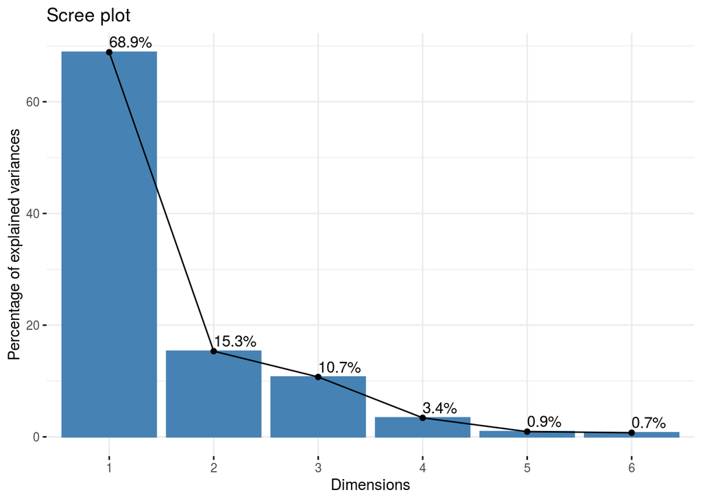

Scree plot – CA of the NDNS RP 9 year data, eating time slots and food goups.

```r
res.ca <- CA(as.data.frame.matrix(freqtab), graph = FALSE)
fviz_screeplot(res.ca, addlabels = TRUE)
```

First two dimensions represents 84.2% of the inertia (variation in time slots profile).

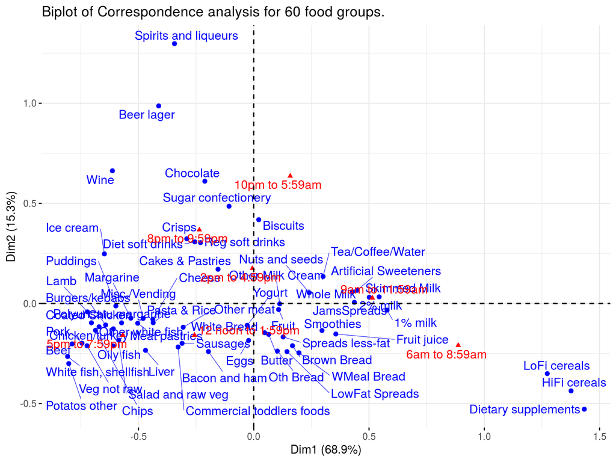

```r
fviz_ca_biplot(res.ca, repel = TRUE, title = "Biplot of Correspondence analysis for 60 food groups.")
```

- The horizontal axis contrasts the early time (am, and earlier than 6 am included) with later time (noon, afternoon, till 10 pm); and breakfast foods with the others.
- The vertical axis shows large contribution from alcohol against the others.

### 2.1.3 Biplot by food healthiness (1)

#### 2.1.3.1 Three healthy food only

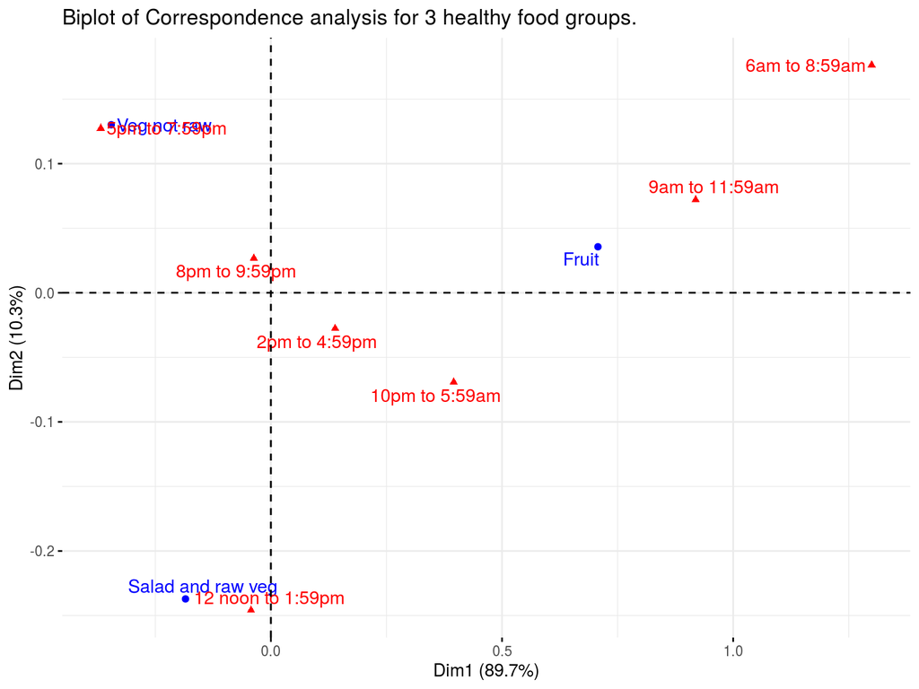

```r
HealthyFoods <- as.data.frame.matrix(freqtab)[rownames(as.data.frame.matrix(freqtab)) %in% c("Veg not raw", "Fruit", "Salad and raw veg"),]

Healthy.ca <- CA(HealthyFoods, graph = FALSE)
fviz_ca_biplot(Healthy.ca,
               repel = TRUE, title = "Biplot of Correspondence analysis for 3 healthy food groups.")
```

#### 2.1.3.3 Neutral food (n = 26)

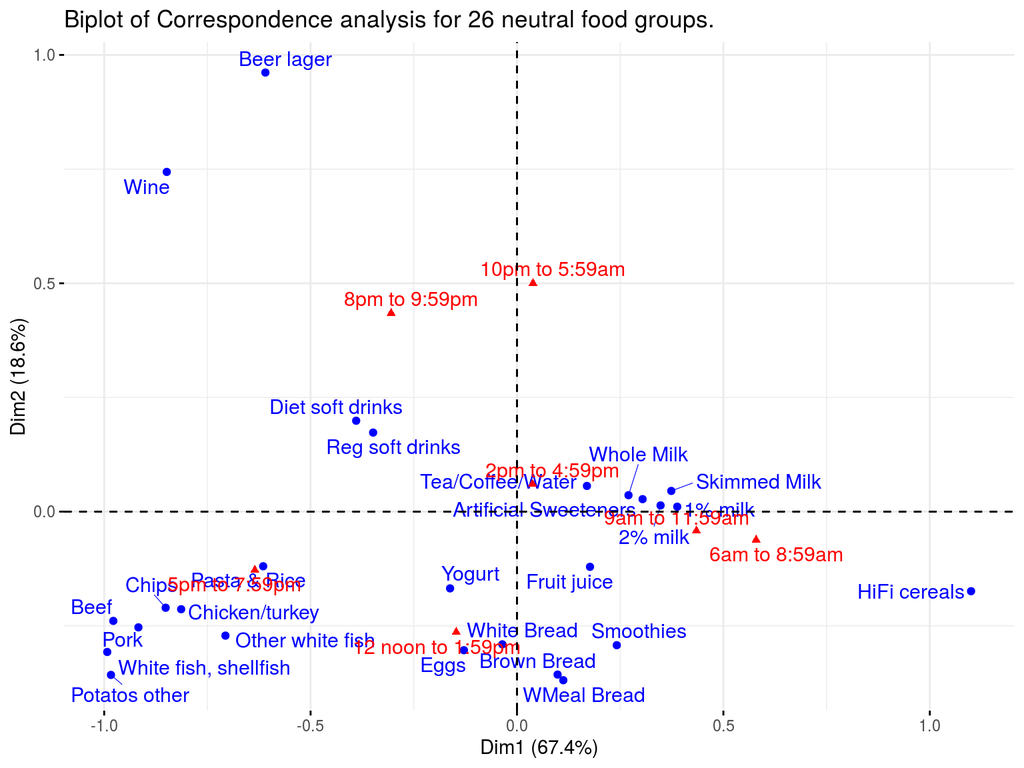

```r
NeutralFoods <- as.data.frame.matrix(freqtab)[rownames(as.data.frame.matrix(freqtab)) %in% TableFoogGroup$mfgLab[TableFoogGroup$neutral],]

Neutral.ca <- CA(NeutralFoods, graph = FALSE)
fviz_ca_biplot(Neutral.ca,
               repel = TRUE, title = "Biplot of Correspondence analysis for 26 neutral food groups.")
```

#### 2.1.3.5 less healthy food (n = 31)

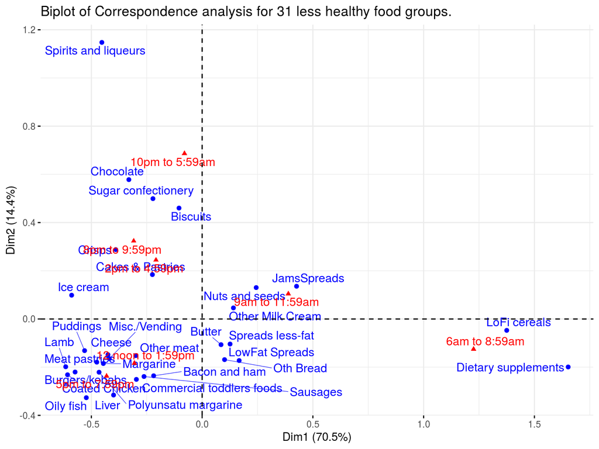

```r
LessFoods <- as.data.frame.matrix(freqtab)[rownames(as.data.frame.matrix(freqtab)) %in% TableFoogGroup$mfgLab[TableFoogGroup$lesshealthy],]

Less.ca <- CA(LessFoods, graph = FALSE)
fviz_ca_biplot(Less.ca,
               repel = TRUE, title = "Biplot of Correspondence analysis for 31 less healthy food groups.")
```

### 2.1.4 Biplot by food healthiness (2)

#### 2.1.4.1 Food Healthiness Group 1

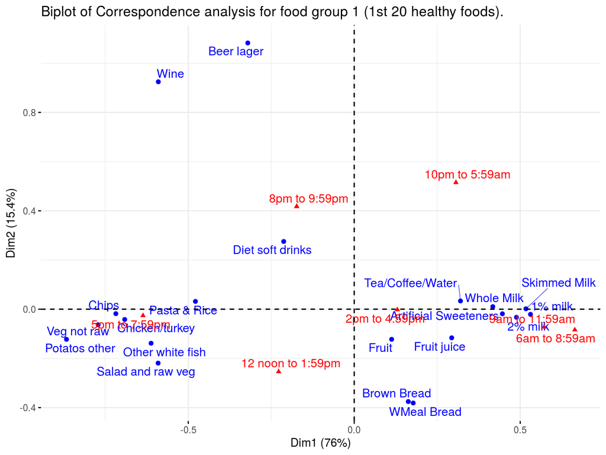

```r
G1Foods <- as.data.frame.matrix(freqtab)[rownames(as.data.frame.matrix(freqtab)) %in% TableFoogGroup$mfgLab[TableFoogGroup$HealthPoints3g == 1],]

G1.ca <- CA(G1Foods, graph = FALSE)
fviz_ca_biplot(G1.ca,
               repel = TRUE, title = "Biplot of Correspondence analysis for food group 1 (1st 20 healthy foods).")
```

#### 2.1.4.2 Food Healthiness Group 2

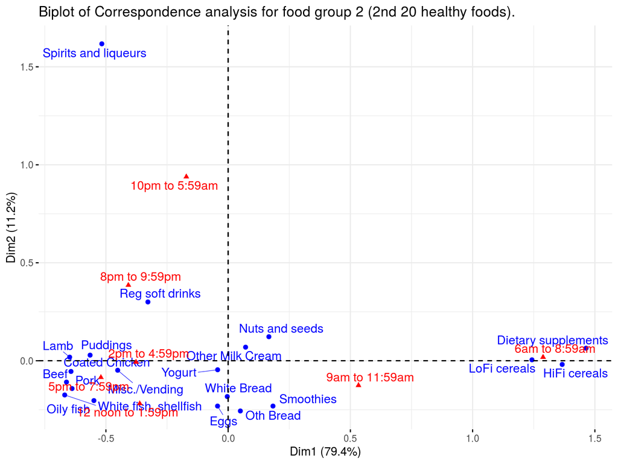

```r
G2Foods <- as.data.frame.matrix(freqtab)[rownames(as.data.frame.matrix(freqtab)) %in% TableFoogGroup$mfgLab[TableFoogGroup$HealthPoints3g == 2],]

G2.ca <- CA(G2Foods, graph = FALSE)
fviz_ca_biplot(G2.ca,
               repel = TRUE, title = "Biplot of Correspondence analysis for food group 2 (2nd 20 healthy foods).")
```

#### 2.1.4.3 Food Healthiness Group 3

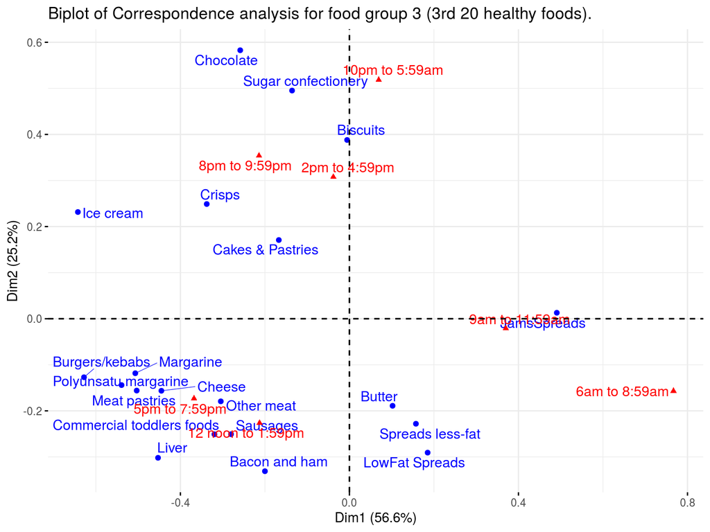

```r
G3Foods <- as.data.frame.matrix(freqtab)[rownames(as.data.frame.matrix(freqtab)) %in% TableFoogGroup$mfgLab[TableFoogGroup$HealthPoints3g == 3],]

G3.ca <- CA(G3Foods, graph = FALSE)
fviz_ca_biplot(G3.ca,
               repel = TRUE, title = "Biplot of Correspondence analysis for food group 3 (3rd 20 healthy foods).")
```

# 3 CA analysis by diabetes status

## 3.1 among diagnosed diabete patients

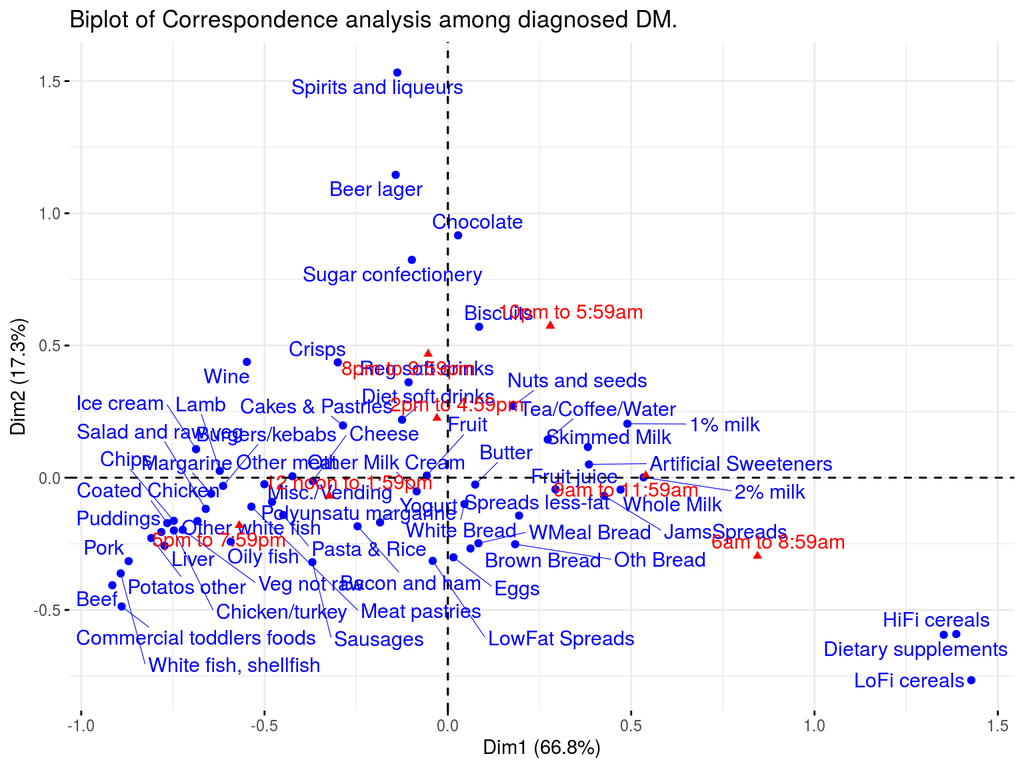

```r
DiagDM <- as.logical(HFood$DM4cat.y == 3)
DiagDMtab <- xtabs(~HFood$mfgLab + HFood$MealTimeSlot, subset = DiagDM)
DiagDMmatrix <- matrix(data = DiagDMtab, nrow = 59, ncol = 7,
                  dimnames = list(rownames(DiagDMtab), colnames(DiagDMtab)))

DiagDM.ca <- CA(DiagDMmatrix, graph = FALSE)
fviz_ca_biplot(DiagDM.ca,
               repel = TRUE, title = "Biplot of Correspondence analysis among diagnosed DM.")
```

## 3.2 among non-diabete participants

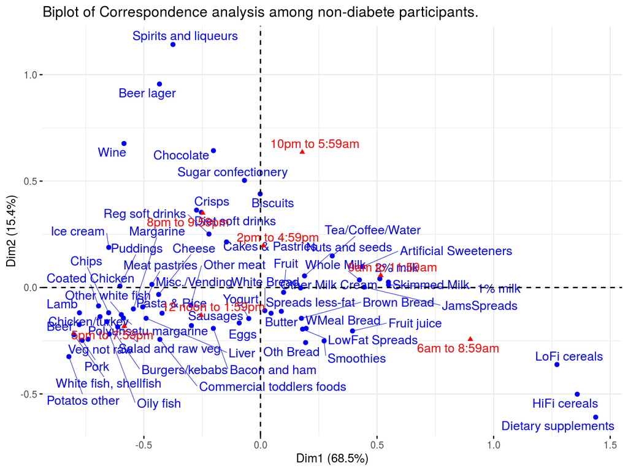

```r
DiagDM <- as.logical(HFood$DM4cat.y == 0)
DiagDMtab <- xtabs(~HFood$mfgLab + HFood$MealTimeSlot, subset = DiagDM)
DiagDMmatrix <- matrix(data = DiagDMtab, nrow = 60, ncol = 7,
                  dimnames = list(rownames(DiagDMtab), colnames(DiagDMtab)))

DiagDM.ca <- CA(DiagDMmatrix, graph = FALSE)
fviz_ca_biplot(DiagDM.ca,
               repel = TRUE, title = "Biplot of Correspondence analysis among non-diabete participants.")
```

## 3.3 among Pre-diabetes participants

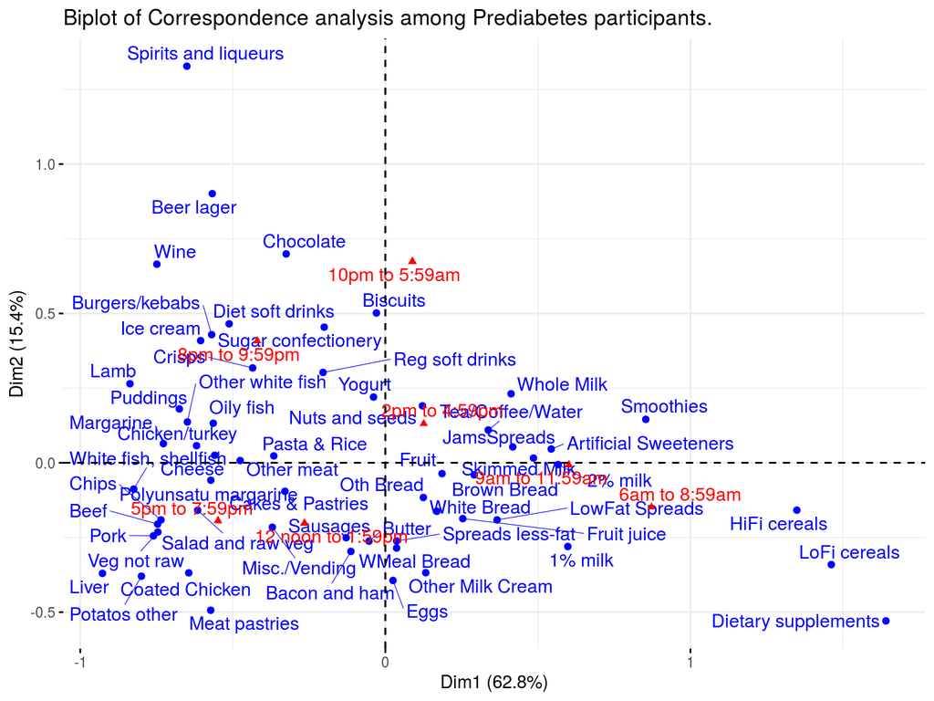

```r
DiagDM <- as.logical(HFood$DM4cat.y == 1)
DiagDMtab <- xtabs(~HFood$mfgLab + HFood$MealTimeSlot, subset = DiagDM)
DiagDMmatrix <- matrix(data = DiagDMtab, nrow = 59, ncol = 7,
                  dimnames = list(rownames(DiagDMtab), colnames(DiagDMtab)))

DiagDM.ca <- CA(DiagDMmatrix, graph = FALSE)
fviz_ca_biplot(DiagDM.ca,
               repel = TRUE, title = "Biplot of Correspondence analysis among Prediabetes participants.")
```

## 3.4 among undiagnosed-diabetes participants

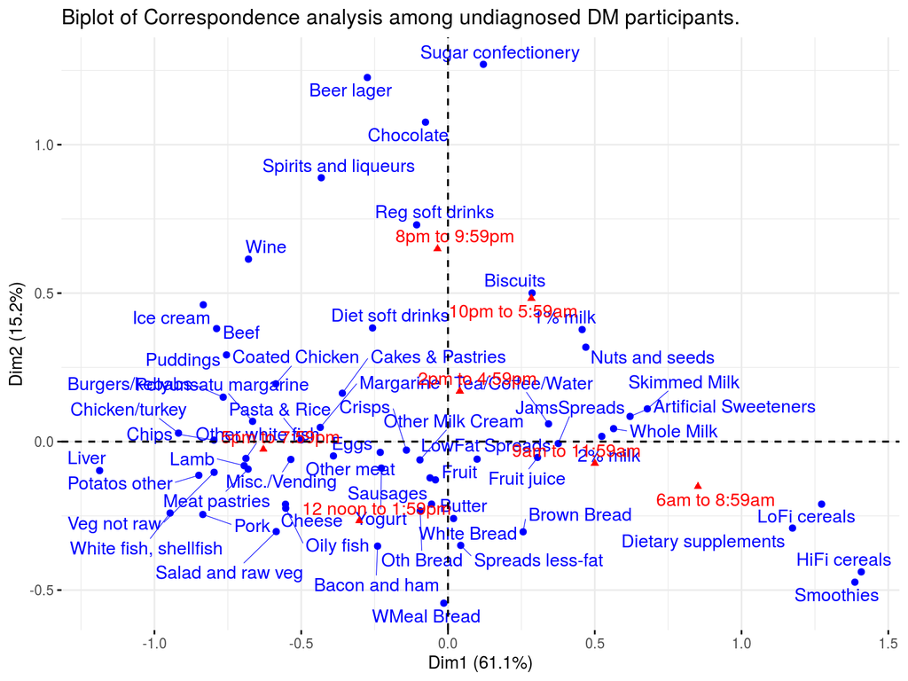

```r
DiagDM <- as.logical(HFood$DM4cat.y == 2)
DiagDMtab <- xtabs(~HFood$mfgLab + HFood$MealTimeSlot, subset = DiagDM)
DiagDMmatrix <- matrix(data = DiagDMtab, nrow = 59, ncol = 7,
                  dimnames = list(rownames(DiagDMtab), colnames(DiagDMtab)))

DiagDM.ca <- CA(DiagDMmatrix, graph = FALSE)
fviz_ca_biplot(DiagDM.ca,
               repel = TRUE, title = "Biplot of Correspondence analysis among undiagnosed DM participants.")
```